# Clase 7. Prueba t de Student.

#### **1. Cargar paquetes.**

En esta clase utilizaremos `ggplot2` (incluido en `tidyverse`) y `readxl` para importar los datos.

```r
library(tidyverse)
library(readxl)
```

#### **2. La prueba t de Student.**

La prueba t de Student es un test estadístico que permite comparar las medias de dos grupos y determinar si las diferencias observadas entre ellas son estadísticamente significativas o si podrían deberse al azar.

La lógica del test parte de una **hipótesis nula (H₀)**, que asume que las dos muestras provienen de poblaciones con la misma media, es decir, que no hay diferencias reales entre los grupos. Luego se calcula un estadístico **t** y se obtiene un **valor p**. Si el valor p es menor a 0.05, rechazamos la hipótesis nula y concluimos que sí existen diferencias estadísticamente significativas entre los grupos.

En R, la prueba t se realiza con la función `t.test()`. La sintaxis utiliza el símbolo `~` para separar la variable cuantitativa (lo que queremos comparar) de la variable cualitativa (los grupos):

```r
t.test(variable_cuantitativa ~ variable_cualitativa, data = nombre_datos)
```

#### **3. Ejercicio 1: Largo de cráneo en *T. rex* y *T. bataar*.**

Realice un test t para comparar las medias de largo de cráneo (m) de *T. rex* y *T. bataar*. Se asume como hipótesis nula que las dos muestras fueron tomadas de poblaciones con las mismas medias, por lo tanto no existen diferencias estadísticamente significativas entre ellas.

##### **3.1. Importar y explorar los datos.**

```r
dinosaurio <- read_excel("~/Desktop/work/0_Cuantitativa_2026/ANT305Q-2026/Clases/Clase7/Dinosaurio.xlsx")
dinosaurio
```

```
## # A tibble: 16 × 2
##    Dinosaurio Largo
##    <chr>      <dbl>
##  1 Trex        0.82
##  2 Trex        0.88
##  3 Trex        0.79
##  4 Trex        0.79
##  5 Trex        0.8
##  6 Trex        0.9
##  7 Trex        0.74
##  8 Trex        0.84
##  9 Trex        0.82
## 10 Tbataar     0.76
## 11 Tbataar     0.82
## 12 Tbataar     0.73
## 13 Tbataar     0.84
## 14 Tbataar     0.73
## 15 Tbataar     0.68
## 16 Tbataar     0.69
```

Exploramos los datos con un boxplot antes de correr el test.

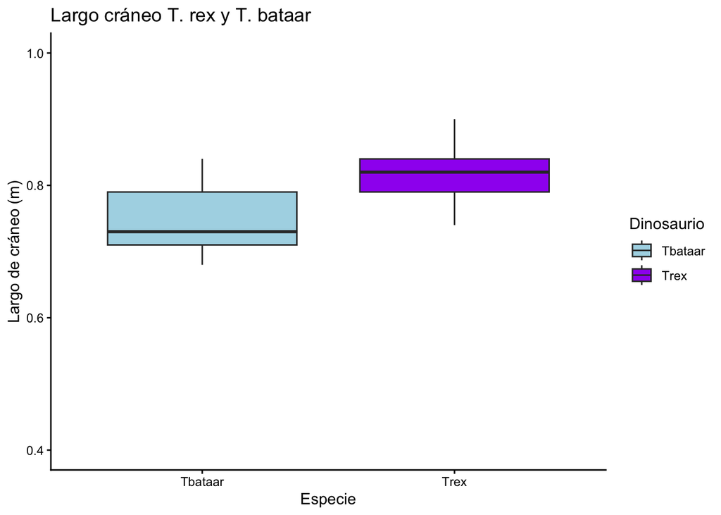

```r
ggplot(data = dinosaurio, aes(x = Dinosaurio, y = Largo, fill = Dinosaurio)) +
  geom_boxplot() +
  scale_y_continuous(limits = c(0.40, 1.00)) +
  scale_fill_manual(values = c("lightblue", "purple")) +
  labs(x = "Especie", y = "Largo de cráneo (m)", title = "Largo cráneo T. rex y T. bataar") +
  theme_classic()
```

##### **3.2. Correr el test t.**

```r
t.test(Largo ~ Dinosaurio, data = dinosaurio)
```

```
##
##  Welch Two Sample t-test
##
## data:  Largo by Dinosaurio
## t = -2.4792, df = 11.327, p-value = 0.03006
## alternative hypothesis: true difference in means between group Tbataar and group Trex is not equal to 0
## 95 percent confidence interval:
##  -0.13192711 -0.00807289
## sample estimates:
## mean in group Tbataar    mean in group Trex
##                  0.75                  0.82
```

##### **3.3. Interpretación.**

¿Qué resultados entrega el test? ¿Podemos rechazar la hipótesis nula? ¿Son dinosaurios del mismo tamaño o no? ¿Por qué?

#### **4. Ejercicio 2: Isótopos de nitrógeno en Quillagua.**

Realice un test t para comparar las medias de isótopos de nitrógeno en los sectores Alto y Bajo del Cementerio Oriente de Quillagua. Se asume que las dos muestras fueron tomadas de poblaciones que tienen las mismas medias para isótopos de nitrógeno, por lo tanto no existen diferencias estadísticamente significativas entre ellas.

##### **4.1. Importar y explorar los datos.**

```r
quillagua <- read_excel("~/Desktop/work/0_Cuantitativa_2026/ANT305Q-2026/Clases/Clase7/Nitrogeno_Quillagua.xlsx")
quillagua
```

```
## # A tibble: 20 × 2
##    Sector  d15N
##    <chr>  <dbl>
##  1 Alto    23.4
##  2 Alto    20.4
##  3 Alto    20.1
##  4 Alto    17.3
##  5 Alto    15.0
##  6 Alto    25.1
##  7 Alto    15.5
##  8 Alto    18.4
##  9 Alto    12.5
## 10 Bajo    16.7
## 11 Bajo    16.7
## 12 Bajo    20.7
## 13 Bajo    17.7
## 14 Bajo    15.7
## 15 Bajo    14.4
## 16 Bajo    22.4
## 17 Bajo    14.5
## 18 Bajo    15.7
## 19 Bajo    18.7
## 20 Bajo    16.9
```

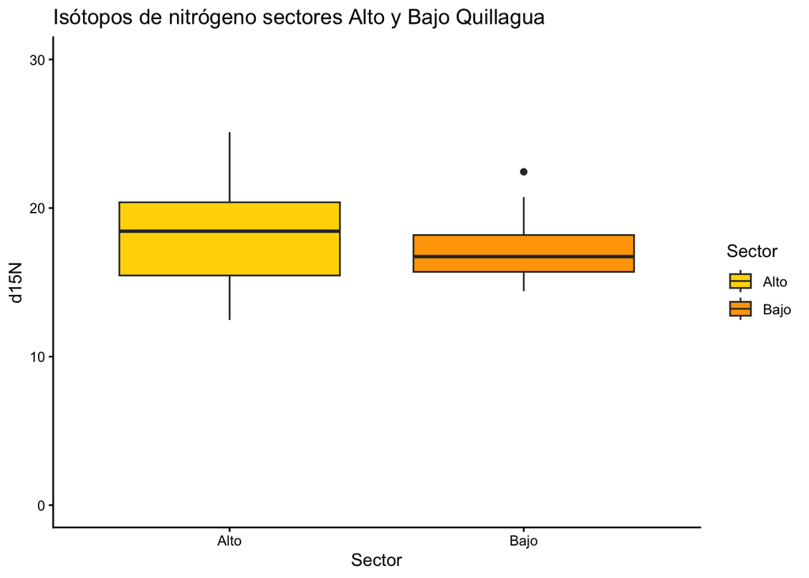

```r
ggplot(data = quillagua, aes(x = Sector, y = d15N, fill = Sector)) +
  geom_boxplot() +
  scale_y_continuous(limits = c(0, 30)) +
  scale_fill_manual(values = c("gold", "orange")) +
  labs(x = "Sector", y = "d15N", title = "Isótopos de nitrógeno sectores Alto y Bajo Quillagua") +
  theme_classic()
```

##### **4.2. Correr el test t.**

```r
t.test(d15N ~ Sector, data = quillagua)
```

```
##
##  Welch Two Sample t-test
##
## data:  d15N by Sector
## t = 0.86247, df = 12.714, p-value = 0.4044
## alternative hypothesis: true difference in means between group Alto and group Bajo is not equal to 0
## 95 percent confidence interval:
##  -2.023807  4.703284
## sample estimates:
## mean in group Alto mean in group Bajo
##           18.62939           17.28966
```

##### **4.3. Interpretación.**

¿Qué resultados entrega el test? ¿Podemos rechazar la hipótesis nula? ¿Qué ocurre con las dietas en Quillagua?

#### **5. Ejercicio 3: Largo de fémur en Quillagua.**

Realice un test t para comparar las medias de largo de fémur (mm) de los sectores Alto y Bajo del Cementerio Oriente de Quillagua. Se asume que las dos muestras fueron tomadas de poblaciones que tienen las mismas medias para largo de fémur, por lo tanto no existen diferencias estadísticamente significativas entre ellas.

##### **5.1. Importar y explorar los datos.**

```r
femur <- read_excel("~/Desktop/work/0_Cuantitativa_2026/ANT305Q-2026/Clases/Clase7/Largo_femur_adultos.xlsx")
femur
```

```
## # A tibble: 91 × 2
##    Sector Largo
##    <chr>  <dbl>
##  1 alto     444
##  2 alto     440
##  3 alto     435
##  4 alto     425
##  5 alto     420
##  6 alto     417
##  7 alto     416
##  8 alto     415
##  9 alto     414
## 10 alto     413
## # ℹ 81 more rows
```

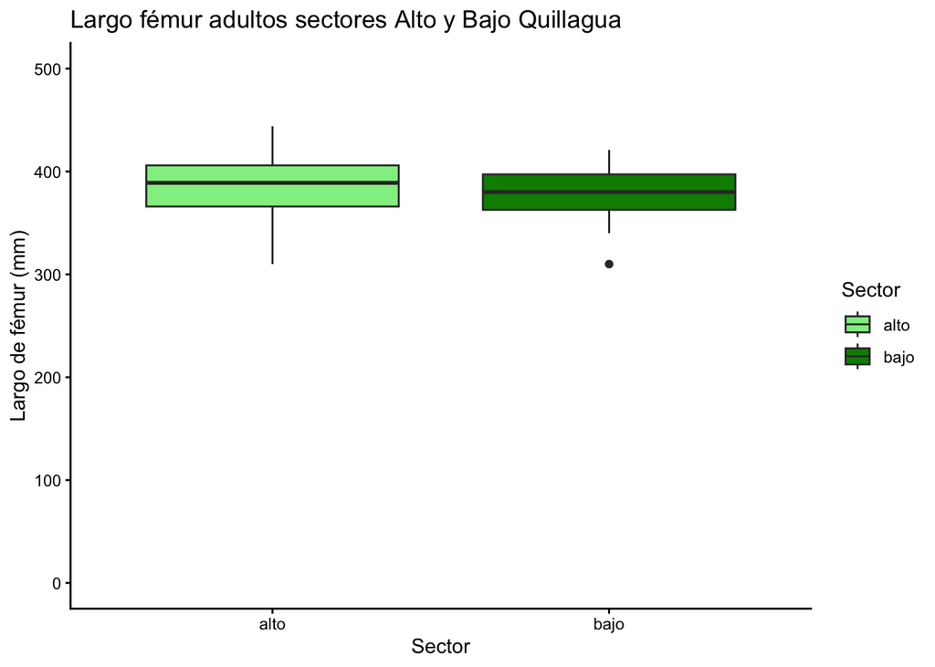

```r
ggplot(data = femur, aes(x = Sector, y = Largo, fill = Sector)) +
  geom_boxplot() +
  scale_y_continuous(limits = c(0, 500)) +
  scale_fill_manual(values = c("lightgreen", "green4")) +
  labs(x = "Sector", y = "Largo de fémur (mm)", title = "Largo fémur adultos sectores Alto y Bajo Quillagua") +
  theme_classic()
```

##### **5.2. Correr el test t.**

```r
t.test(Largo ~ Sector, data = femur)
```

```
##
##  Welch Two Sample t-test
##
## data:  Largo by Sector
## t = 1.3225, df = 88.158, p-value = 0.1894
## alternative hypothesis: true difference in means between group alto and group bajo is not equal to 0
## 95 percent confidence interval:
##  -3.713256 18.488766
## sample estimates:
## mean in group alto mean in group bajo
##           386.3878           379.0000
```

##### **5.3. Interpretación.**

¿Qué resultados entrega el test? ¿Podemos rechazar la hipótesis nula? ¿Hay diferencias de estatura entre los cementerios? ¿Si las hay o no, ¿a qué podría deberse esto?

#### **6. Trabajo en Clases 7.**

Para esta actividad utilizaremos las bases de datos `Area_de_sitio.xlsx` y `Tabla_camelida.xlsx`. Puedes encontrarlas en el repositorio del curso.

1. Realice un test t para comparar las áreas de sitios de dos ocupaciones arqueológicas, una de la Edad del Bronce Temprana (EBTE) y otra de la Edad del Bronce Tardía (EBTA). Recuerde explorar los datos primero mediante un boxplot. Se asume que las dos muestras fueron tomadas de poblaciones que poseen las mismas medias para área de sitio (ha), por lo tanto no deberían existir diferencias estadísticamente significativas entre ellas. Ponga a prueba esta hipótesis nula y entregue una interpretación arqueológica de sus resultados.
2. Utilice los datos de `Tabla_camelida.xlsx` y compare la variable `Largo` (mm) entre Llama y Guanaco. ¿Podríamos plantear que las muestras de largo de falange para llama y guanaco provienen de poblaciones con las mismas medias? ¿Cuál sería su hipótesis nula? Corrobórela mediante una prueba t de Student. Recuerde explorar los datos primero mediante un boxplot y entregue una interpretación arqueológica de sus resultados.
3. Continúe utilizando los datos de `Tabla_camelida.xlsx`, pero esta vez analice los datos de `Ancho` de falange comparando Llama y Guanaco. ¿Estas muestras provendrían de poblaciones con las mismas medias para ancho de falange? Plantee una hipótesis nula y evalúela mediante una prueba t de Student. Recuerde explorar los datos primero mediante un boxplot y entregue una interpretación arqueológica de sus resultados.

← Clase Anterior Índice Siguiente Clase →